# ARMA Theory Examples

Author

Affiliation

Miguel A. Arranz

Universidad Carlos III de Madrid

## Introduction

**ARMA Theory** is an educational Python library for exploring the theoretical properties of autoregressive moving-average (ARMA) models from user-specified AR and MA coefficients.

This document illustrates the main tools provided by the library. The examples focus on the relationship between the coefficients of an ARMA model and its theoretical properties, including causality, invertibility, autocorrelation, dynamic responses to innovations, and long-run responses.

The library does not estimate ARMA models from data. All the examples in this document therefore start from specified population parameters.

## Setup

The examples assume that the repository has been cloned and the `arma_theory` environment has been created and activated. See the project README for installation instructions.

The library can then be imported directly from the repository directory:

```python
import arma_theory as arma
```

All functions in the examples below are called through the `arma` namespace, for example `arma.arma_diagnostics()`, `arma.arma_acf()`, and `arma.arma_dynamics()`.

## Model Convention

ARMA Theory uses the convention

$$y_t
=
\varphi_1 y_{t-1}+\cdots+\varphi_p y_{t-p}
+\varepsilon_t
+\theta_1\varepsilon_{t-1}+\cdots+\theta_q\varepsilon_{t-q},$$

or equivalently,

$$\varphi(L)y_t=\theta(L)\varepsilon_t,$$

where

$$\varphi(L)=1-\varphi_1L-\cdots-\varphi_pL^p,
\qquad
\theta(L)=1+\theta_1L+\cdots+\theta_qL^q.$$

The coefficients supplied to Python follow these signs directly. For example,

```python
ar = [0.6, -0.2]
ma = [0.5]
```

specifies the ARMA(2,1) model

$$y_t=0.6y_{t-1}-0.2y_{t-2}
+\varepsilon_t+0.5\varepsilon_{t-1}.$$

Use an empty list when a component is absent: `ar=[]` for a pure MA model and `ma=[]` for a pure AR model.

## Polynomial Diagnostics

The properties of an ARMA model depend on the roots of its AR and MA polynomials. `arma.arma_diagnostics()` computes these roots and uses them to assess causality, stationarity, invertibility, and possible common roots.

We continue with the ARMA(2,1) model defined above:

```python
diagnostics = arma.arma_diagnostics(ar=ar, ma=ma)

print("Causal:", diagnostics["causal"])
print("Invertible:", diagnostics["invertible"])
print("Minimal representation:", diagnostics["minimal_representation"])
```

```
Causal: True
Invertible: True
Minimal representation: True
```

The model is causal when all roots of the AR polynomial lie outside the unit circle and invertible when all roots of the MA polynomial lie outside the unit circle.

### Polynomial Roots

The AR and MA roots can be examined directly:

```python
print("AR roots:", diagnostics["ar_roots"])
print("MA roots:", diagnostics["ma_roots"])
```

```
AR roots: [1.5+1.6583124j 1.5-1.6583124j]
MA roots: [-2.+0.j]
```

It is often more intuitive to examine the **inverse roots**, since causality and invertibility then require the corresponding inverse roots to lie inside the unit circle:

```python
print("Inverse AR roots:", diagnostics["inverse_ar_roots"])
print("Inverse MA roots:", diagnostics["inverse_ma_roots"])
```

```
Inverse AR roots: [0.3-0.33166248j 0.3+0.33166248j]
Inverse MA roots: [-0.5-0.j]
```

### Inverse-Root Plot

The inverse roots can also be represented in the complex plane. Causality and invertibility require the corresponding inverse roots to lie inside the unit circle.

```
(<Figure size 624x624 with 1 Axes>,
 <Axes: title={'center': 'Inverse Roots of AR and MA Polynomials'}, xlabel='Real part', ylabel='Imaginary part'>)
```

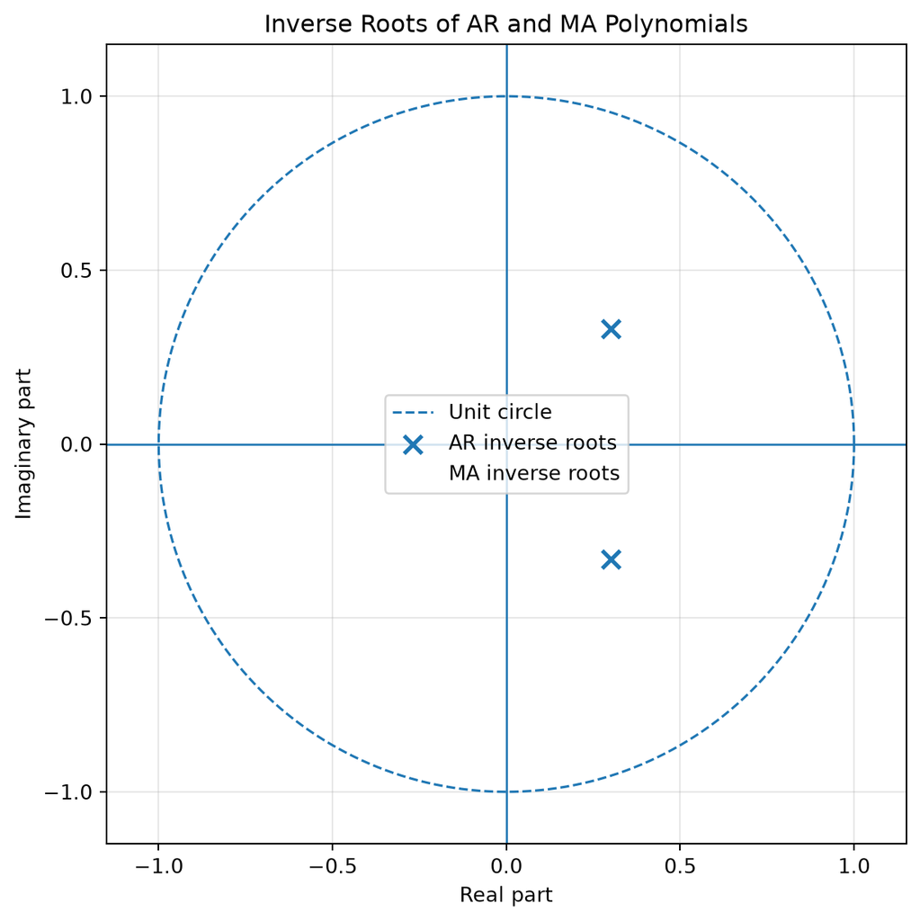

```python
arma.plot_arma_inverse_roots(ar=ar, ma=ma)
```

### Common Roots and Minimal Representations

An ARMA specification is not a minimal representation when the AR and MA polynomials have a common root.

Consider

$$y_t = 0.6y_{t-1}+\varepsilon_t-0.6\varepsilon_{t-1}.$$

The corresponding coefficients are:

```python
ar_common = [0.6]
ma_common = [-0.6]
```

We can check for common roots using `arma.arma_diagnostics()`:

```python
diagnostics_common = arma.arma_diagnostics(
    ar=ar_common,
    ma=ma_common
)

print("Common roots:", diagnostics_common["common_roots"])
print("Minimal representation:", diagnostics_common["minimal_representation"])
print("Common root pairs:", diagnostics_common["common_root_pairs"])
```

```
Common roots: True
Minimal representation: False
Common root pairs: [{'ar_index': 0, 'ma_index': 0, 'ar_root': np.complex128(1.6666666666666667+0j), 'ma_root': np.complex128(1.6666666666666667+0j), 'relative_distance': 0.0}]
```

In this example the AR and MA polynomials contain the same factor. The ARMA(1,1) specification is therefore not a minimal representation.

The common root can also be seen in the inverse-root plot:

```
(<Figure size 624x624 with 1 Axes>,
 <Axes: title={'center': 'Inverse Roots of AR and MA Polynomials'}, xlabel='Real part', ylabel='Imaginary part'>)
```

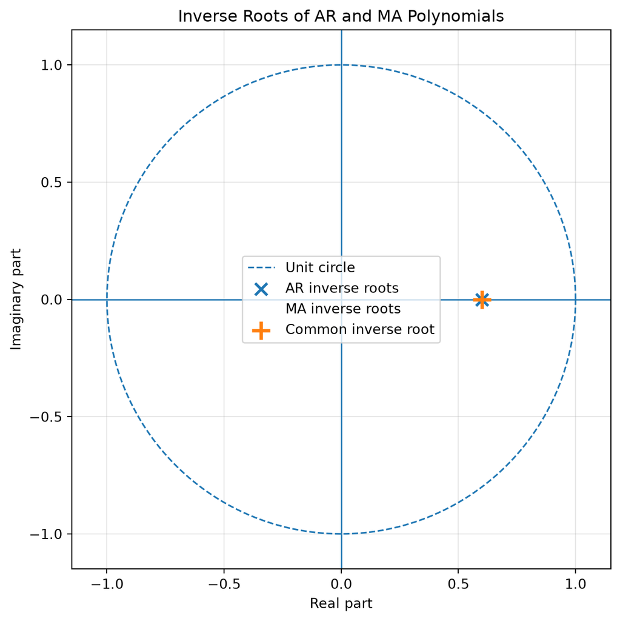

```python
arma.plot_arma_inverse_roots(
    ar=ar_common,
    ma=ma_common
)
```

## Dynamic Responses

For a causal ARMA model, the effect of an innovation can be represented through its $\psi$-weights,

$$y_t = \psi(L)\varepsilon_t
= \sum_{j=0}^{\infty}\psi_j\varepsilon_{t-j}.$$

The first $\psi$-weights of the ARMA(2,1) model can be computed with:

```python
psi = arma.arma_psi_weights(
    ar=ar,
    ma=ma,
    n_terms=10
)

psi
```

```
array([ 1.000000e+00,  1.100000e+00,  4.600000e-01,  5.600000e-02,
       -5.840000e-02, -4.624000e-02, -1.606400e-02, -3.904000e-04,
        2.978560e-03,  1.865216e-03])
```

The coefficient $\psi_j$ measures the effect at horizon $j$ of a unit innovation in $\varepsilon_t$.

### Cumulative and Long-Run Responses

`arma.arma_dynamics()` combines the $\psi$-weights with their cumulative response and, when the model is causal, computes the long-run response.

```python
dynamics = arma.arma_dynamics(
    ar=ar,
    ma=ma,
    horizon=20
)

arma.arma_summary(dynamics)
```

```
ARMA Dynamic Analysis
==========================================
Causal model ............. True
Long-run response ........ 2.500000
Analysis horizon ......... 20

 Horizon        psi_j   Cumulative psi
--------------------------------------
       0       1.0000           1.0000
       1       1.1000           2.1000
       2       0.4600           2.5600
       3       0.0560           2.6160
       4      -0.0584           2.5576
       5      -0.0462           2.5114
       6      -0.0161           2.4953
       7      -0.0004           2.4949
       8       0.0030           2.4979
       9       0.0019           2.4997
      10       0.0005           2.5003
      11      -0.0001           2.5002
      12      -0.0001           2.5001
      13      -0.0001           2.5000
      14      -0.0000           2.5000
      15       0.0000           2.5000
      16       0.0000           2.5000
      17       0.0000           2.5000
      18       0.0000           2.5000
      19      -0.0000           2.5000
      20      -0.0000           2.5000
```

The cumulative response at horizon $j$ is

$$\sum_{i=0}^{j}\psi_i.$$

For a causal ARMA model, the long-run response to a unit innovation is

$$\sum_{j=0}^{\infty}\psi_j
=
\frac{\theta(1)}{\varphi(1)}
=
\frac{1+\sum_{j=1}^{q}\theta_j}
{1-\sum_{i=1}^{p}\varphi_i}.$$

The cumulative response therefore approaches the long-run response as the horizon increases.

### Dynamic and Cumulative Response Plots

The dynamic response to a unit innovation can be visualized directly:

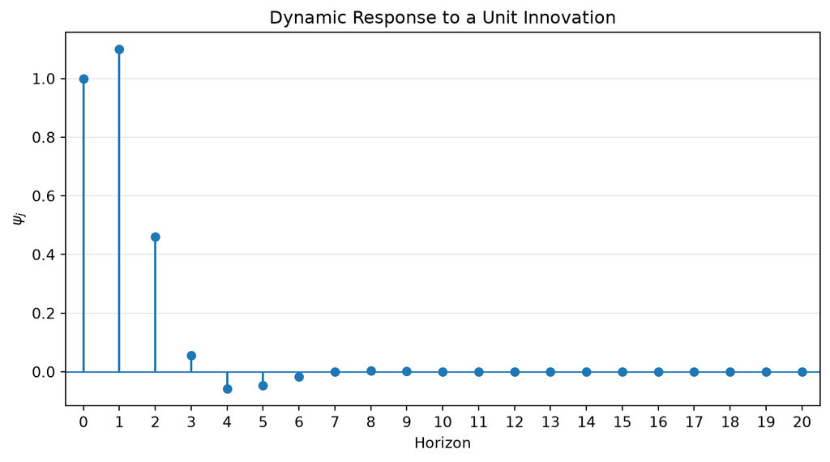

```python
fig, ax = arma.plot_arma_dynamic_response(
    ar=ar,
    ma=ma,
    horizon=20
)
```

The graph shows the sequence of $\psi$-weights and therefore how the effect of a unit innovation evolves over time.

The corresponding cumulative response is:

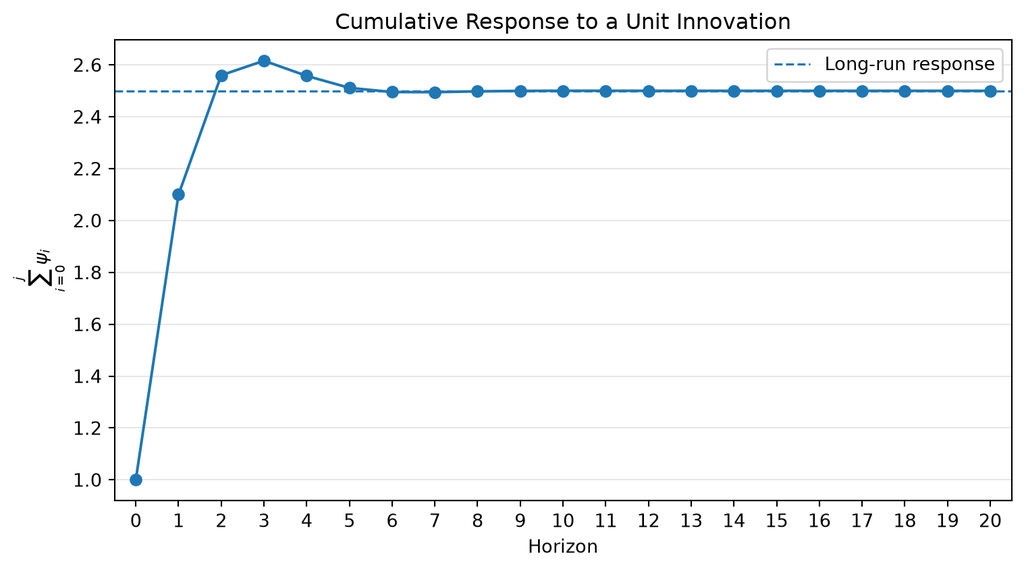

```python
fig, ax = arma.plot_arma_cumulative_response(
    ar=ar,
    ma=ma,
    horizon=20
)
```

For a causal model, the cumulative-response plot also shows the analytical long-run response, making it possible to see how quickly the cumulative effects approach their limiting value.